# Final Project: Is AIS an Effective Tool for Ships to Avoid Whale Watch Boat Aggregtions?

Laura Howes

2018 Decemeber

# INTRODUCTION

#### Ship strike is one of the leading causes of serious injury and mortality to large whales (Thomas et al. 2015). While there have been many measures to mitigate this problem, ship strikes continue (van Der Hoop et al. 2013). For example, the critically endangered North Atlantic right whales are unresponsive to ship noise and have either negative or no reactions to alerting stimuli (Nowacek et al. 2004). Nowacek et al. (2004) found that alerting stimuli from vessels cause right whales to come up to the surface more frequently, proving greater risk to getting hit by a vessel. Large ship operators have utilized marine mammal observers, but observers are limited by personnel and type of ship.

#### Automatic Identification System (AIS) is a technology that provides ship position reports with location, time, and identification information. All ocean-going commercial traffic greater than 300 tons, vessels carrying 165 or more passengers, and tugs are required to carry AIS transmitters (Federal Register 2003; IALA 2004). NOAA’s Stellwagen Bank National Marine Sanctuary (SBNMS) installed 3 AIS receivers near Massachusetts Bay to monitor ship traffic transiting the SBNMS. Using this data, record of ship traffic patterns can be described, including commercial whale watch boats. AIS data have been a useful tool in the SBNMS for conservation management, effectively reducing the risk of ship strike (Wiley et al. 2013). However, as ship strike persists and exists in other areas throughout the world, and as new shifts in large whale distributions are observed (Davis et al. 2017), additional measures to protect large whales are still needed.

#### The question of this study is to investigate whether large commercial ships change their traffic patterns when they detect whale watch boats via AIS in the Boston Traffic Separation Scheme (TSS). If ships deviated from their intended track due to whale watch boats detected on AIS, this essentially helps create a buffer for large whale aggregations during the whale watch season.

# METHODS

### Model Creation

#### To measure whether ships are changing their track line, deviations from their outgoing/ingoing travel path needed to be measured. Predictors that would show ship operator reactions would be: 1) Presence of AIS on whale watch boats, 2) Time of day, 3) Turning of the ship, 4) Change in velocity, and 5) Distance from whale watch boats when ship starts to turn/change velocity

#### Visualization of model and predictors is show in Figure 1:

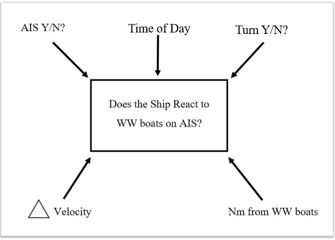

Figure 1 - Model Design

### Simulated Data

#### As this was an experimental design, simulated data was produced via RStudio as seen in Figure 2. The control group, named “WW_AIS_N”, consisted of days without whale watch boats reported via AIS in the TSS. The experimental group, “WW_AIS_Y”, consisted of days with whale watch boats reported via AIS. Simulated data assumed a normal distribution and reflected predicted trends in the TSS. “Time of day” column, labeled “Time” assumed a random distribution and was divided into 4 groups: 8:00-10:59 (morning), 2 = 11:00-13:59 (midday), 3 = 14:00- 16:59 (afternoon), 17:00 - 19:59 (evening), as time is not predicted to have a significant effect since whale watch boats only operate during daylight hours. Change in velocity data is referred to as “Knot” in the table and this study, “Turn Y/N” was referred to as “Angle”, and “Distance from whale watch boats was referred to as”Nm_from_boat“.

```r
set.seed(2018)

ship_data_rnorm_Y <- data.frame(WW_AIS = sample(c("Y"), 100, replace = TRUE),angle = (rnorm(100, 45, 10)),knots = (rnorm(100, 10, 3)),time = sample(c(1:4), 100, replace = TRUE),nm_from_boat = (rnorm(100, 15, 5)))

ship_data_rnorm_N <- data.frame(WW_AIS = sample(c("N"), 100, replace = TRUE),angle = (rnorm(100, 0, .5)),knots = (rnorm(100, 5, 1)),time = sample(c(1:4), 100, replace = TRUE),nm_from_boat = (rnorm(100, 0, 0)))

#combined data
ship_data <- rbind(ship_data_rnorm_Y, ship_data_rnorm_N)

ship_data
```

| WW_AIS | angle | knots | time | nm_from_boat |
| --- | --- | --- | --- | --- |
| Y | 39.125572766 | 10.494202 | 4 | 7.668510 |
| Y | 39.725563316 | 11.034203 | 4 | 14.360914 |
| Y | 50.960211604 | 16.835251 | 4 | 17.503704 |
| Y | 32.286875967 | 13.345833 | 1 | 14.879027 |
| Y | 42.987454563 | 11.739091 | 4 | 13.681662 |
| Y | 49.556339121 | 8.764072 | 1 | 20.652131 |
| Y | 35.651730742 | 13.744754 | 1 | 15.215658 |
| Y | 72.283183026 | 10.743079 | 4 | 15.059017 |
| Y | 48.466448687 | 12.010125 | 4 | 15.760441 |
| Y | 38.622902887 | 5.924038 | 2 | 11.365462 |

[output cut: 190 more lines]

##### Figure 2 - Simulated Data set

### Statisical Testing

# RESULTS

### Initial visualization

#### Figure 3 produces a multi-comparison of predictors to look for overall patterns. Box plots were used to compare control and experimental groups for each predictor show in Figure 4. At a visual glace, Angle, Knot, and Nm_from_boat predictors show different ranges and medians (except for Time, which was randomized).

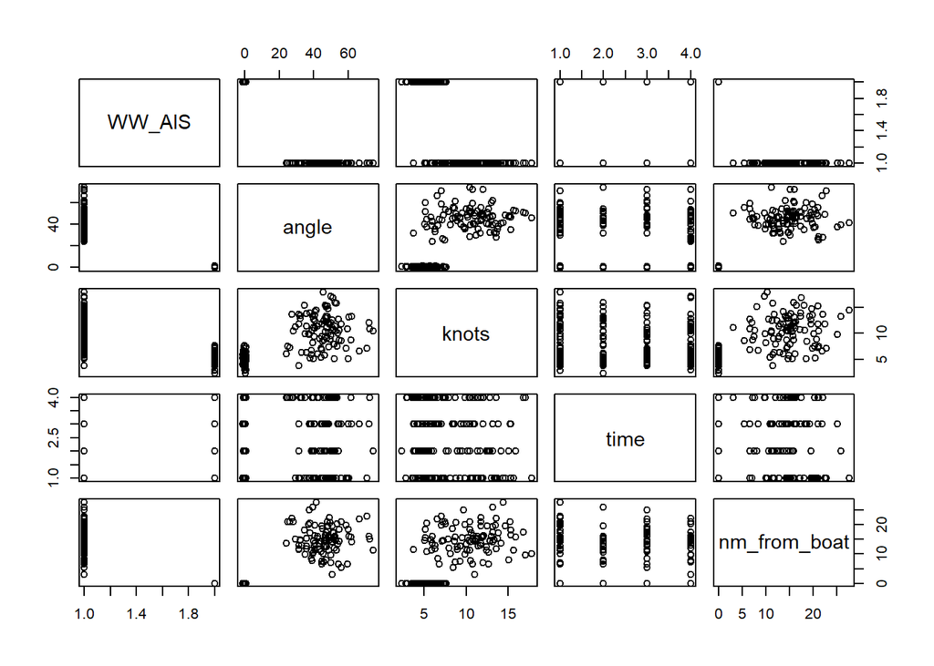

```r
plot(ship_data)
```

```r
#multi-comparisons of predictors
```

##### Figure 3 - Initial visualization for spotting trends

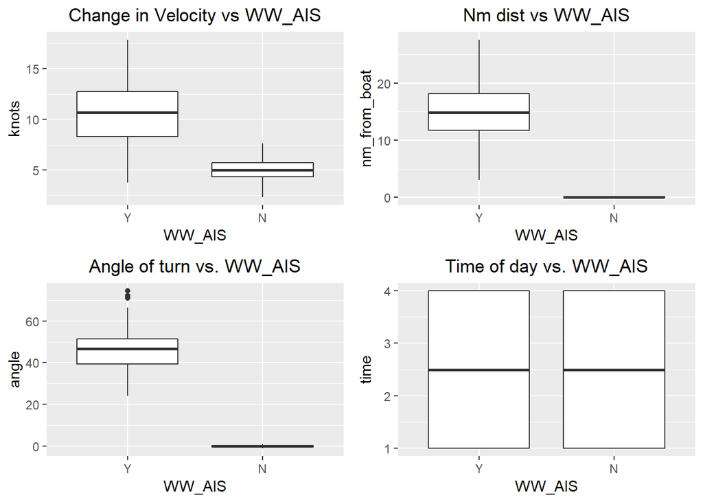

```r
knot <- ggplot(data = ship_data, aes(x = WW_AIS, y = knots)) +
  geom_boxplot() +
  ggtitle("Change in Velocity vs WW_AIS") +
  theme(plot.title = element_text(hjust = 0.5))

nm <- ggplot(data = ship_data, aes(x = WW_AIS, y = nm_from_boat)) +
  geom_boxplot() +
  ggtitle("Nm dist vs WW_AIS") +
  theme(plot.title = element_text(hjust = 0.5))

angle <- ggplot(data = ship_data, aes(x = WW_AIS, y = angle)) +
  geom_boxplot() +
  ggtitle("Angle of turn vs. WW_AIS") +
  theme(plot.title = element_text(hjust = 0.5))

time <- ggplot(data = ship_data, aes(x = WW_AIS, y = time)) +
  geom_boxplot()  +
  ggtitle("Time of day vs. WW_AIS") +
  theme(plot.title = element_text(hjust = 0.5))

knot + nm + angle + time
```

```r
#Comparison of 4 predictors
```

##### Figure 4: Boxplot visualizations to compare medians and symmetry, of the 4 predictors Knot, Nm_from_boat, Angle, and Time.

### Means and Standard Deviations

#### Means and SD were calculated for later power analysis shown in Figures 5 & 6. To prepare data for Welch’s t-tests, data was spread by a factor of WW_AIS Y and N (see Figure 5)

```r
#separated data to test the two means

ship_data_separated <- data.frame(angle_Y = (rnorm(100, 45, 10)),knots_Y = (rnorm(100, 10, 3)),time_Y = sample(c(1:4), 100, replace = TRUE),nm_from_boat_Y = (rnorm(100, 15, 5)),angle_N = (rnorm(100, 0, .5)),knots_N = (rnorm(100, 5, 1)),time_N = sample(c(1:4), 100, replace = TRUE),nm_from_boat_Y = (rnorm(100, 15, 5)),nm_from_boat_N = (rnorm(100, 0, 0)))

head(ship_data_separated)
```

|  | angle_Y | knots_Y | time_Y | nm_from_boat_Y | angle_N | knots_N | time_N | nm_from_boat_Y.1 | nm_from_boat_N |
| --- | --- | --- | --- | --- | --- | --- | --- | --- | --- |
| 1 | 56.23350 | 7.098406 | 3 | 19.020250 | 0.25000625 | 6.246018 | 1 | 10.31144 | 0 |
| 2 | 59.33945 | 15.049130 | 1 | 23.517298 | -0.20977316 | 4.596425 | 2 | 21.83895 | 0 |
| 3 | 42.01952 | 10.283225 | 2 | 16.074706 | -0.01624121 | 4.437061 | 3 | 17.19939 | 0 |
| 4 | 34.54722 | 8.636858 | 1 | 6.040508 | -0.84868282 | 4.417957 | 1 | 10.66273 | 0 |
| 5 | 40.66379 | 15.216230 | 1 | 15.562666 | -0.30243193 | 4.232060 | 3 | 15.36725 | 0 |
| 6 | 49.31665 | 7.619218 | 1 | 19.081317 | 0.45092218 | 3.608371 | 3 | 12.86948 | 0 |

```r
mean_nm_Y <- mean(ship_data_separated$nm_from_boat_Y)
mean_angle_Y <- mean(ship_data_separated$angle_Y)
mean_knots_Y <- mean(ship_data_separated$knots_Y)
mean_time_Y <- mean(ship_data_separated$time_Y)

mean_nm_N <- mean(ship_data_separated$nm_from_boat_N)
mean_angle_N <- mean(ship_data_separated$angle_N)
mean_knots_N <- mean(ship_data_separated$knots_N)
mean_time_N <- mean(ship_data_separated$time_N)

aggregate(nm_from_boat ~ WW_AIS, ship_data, mean)
```

| WW_AIS | nm_from_boat |
| --- | --- |
| Y | 14.94449 |
| N | 0.00000 |

```r
aggregate(knots ~ WW_AIS, ship_data, mean)
```

| WW_AIS | knots |
| --- | --- |
| Y | 10.539496 |
| N | 5.056223 |

```r
aggregate(angle ~ WW_AIS, ship_data, mean)
```

| WW_AIS | angle |
| --- | --- |
| Y | 45.90753005 |
| N | -0.08605721 |

```r
aggregate(time ~ WW_AIS, ship_data, mean)
```

| WW_AIS | time |
| --- | --- |
| Y | 2.46 |
| N | 2.49 |

##### Figure 5: Calculation of means. Data frame was separated into Conrol and Experimental Groups by ww_AIS “Y or N”.

```r
sd_nm_Y <- sd(ship_data_separated$nm_from_boat_Y)
sd_angle_Y <-sd(ship_data_separated$angle_Y)
sd_knots_Y <- sd(ship_data_separated$knots_Y)
sd_time_Y <- sd(ship_data_separated$time_Y)

sd_nm_N <- sd(ship_data_separated$nm_from_boat_N)
sd_angle_N <- sd(ship_data_separated$angle_N)
sd_knots_N <-sd(ship_data_separated$knots_N)
sd_time_N <- sd(ship_data_separated$time_N)

aggregate(nm_from_boat ~ WW_AIS, ship_data, sd)
```

| WW_AIS | nm_from_boat |
| --- | --- |
| Y | 4.679525 |
| N | 0.000000 |

```r
aggregate(knots ~ WW_AIS, ship_data, sd)
```

| WW_AIS | knots |
| --- | --- |
| Y | 3.104718 |
| N | 1.042770 |

```r
aggregate(angle ~ WW_AIS, ship_data, sd)
```

| WW_AIS | angle |
| --- | --- |
| Y | 10.262830 |
| N | 0.480541 |

```r
aggregate(time ~ WW_AIS, ship_data, sd)
```

| WW_AIS | time |
| --- | --- |
| Y | 1.175679 |
| N | 1.167705 |

##### Figure 6: Calculation of standard deviations

### Welch Two-sample t-test

#### All tests, except for the Time t-test, rejected the null that there was no significant difference between the control and experimental means. In Figure 7, p-value results for Angle, Knot, and Nm_from_boat were < 2.2 e-16, showing very high certainty. Time p-value = 0.4587, which accepts the null that there was no significant difference between the control and experimental means, was expected due to the structure of the simulated time data.

```r
#Welch two-sample t-test
t.test(ship_data_separated$nm_from_boat_Y, ship_data_separated$nm_from_boat_N)
```

```
##
##  Welch Two Sample t-test
##
## data:  ship_data_separated$nm_from_boat_Y and ship_data_separated$nm_from_boat_N
## t = 28.511, df = 99, p-value < 2.2e-16
## alternative hypothesis: true difference in means is not equal to 0
## 95 percent confidence interval:
##  13.91404 15.99556
## sample estimates:
## mean of x mean of y
##   14.9548    0.0000
```

```r
t.test(ship_data_separated$knots_Y, ship_data_separated$knots_N)
```

```
##
##  Welch Two Sample t-test
##
## data:  ship_data_separated$knots_Y and ship_data_separated$knots_N
## t = 17.163, df = 129.29, p-value < 2.2e-16
## alternative hypothesis: true difference in means is not equal to 0
## 95 percent confidence interval:
##  4.640591 5.849872
## sample estimates:
## mean of x mean of y
## 10.191029  4.945798
```

```r
t.test(ship_data_separated$angle_Y, ship_data_separated$angle_N)
```

```
##
##  Welch Two Sample t-test
##
## data:  ship_data_separated$angle_Y and ship_data_separated$angle_N
## t = 41.567, df = 99.47, p-value < 2.2e-16
## alternative hypothesis: true difference in means is not equal to 0
## 95 percent confidence interval:
##  42.63647 46.91082
## sample estimates:
##   mean of x   mean of y
## 44.74778020 -0.02586434
```

```r
t.test(ship_data_separated$time_Y, ship_data_separated$time_N)
```

```
##
##  Welch Two Sample t-test
##
## data:  ship_data_separated$time_Y and ship_data_separated$time_N
## t = -0.74252, df = 197.45, p-value = 0.4587
## alternative hypothesis: true difference in means is not equal to 0
## 95 percent confidence interval:
##  -0.4021463  0.1821463
## sample estimates:
## mean of x mean of y
##      2.42      2.53
```

```r
tidy(t.test(ship_data_separated$nm_from_boat_Y, ship_data_separated$nm_from_boat_N))
```

| estimate | estimate1 | estimate2 | statistic | p.value | parameter | conf.low | conf.high | method | alternative |
| --- | --- | --- | --- | --- | --- | --- | --- | --- | --- |
| 14.9548 | 14.9548 | 0 | 28.51141 | 1.563156e-49 | 99 | 13.91404 | 15.99556 | Welch Two Sample t-test | two.sided |

```r
tidy(t.test(ship_data_separated$knots_Y, ship_data_separated$knots_N))
```

| estimate | estimate1 | estimate2 | statistic | p.value | parameter | conf.low | conf.high | method | alternative |
| --- | --- | --- | --- | --- | --- | --- | --- | --- | --- |
| 5.245232 | 10.19103 | 4.945798 | 17.16326 | 3.873157e-35 | 129.2868 | 4.640591 | 5.849872 | Welch Two Sample t-test | two.sided |

```r
tidy(t.test(ship_data_separated$angle_Y, ship_data_separated$angle_N))
```

| estimate | estimate1 | estimate2 | statistic | p.value | parameter | conf.low | conf.high | method | alternative |
| --- | --- | --- | --- | --- | --- | --- | --- | --- | --- |
| 44.77364 | 44.74778 | -0.02586434 | 41.56667 | 1.105353e-64 | 99.47002 | 42.63647 | 46.91082 | Welch Two Sample t-test | two.sided |

```r
tidy(t.test(ship_data_separated$time_Y, ship_data_separated$time_N))
```

| estimate | estimate1 | estimate2 | statistic | p.value | parameter | conf.low | conf.high | method | alternative |
| --- | --- | --- | --- | --- | --- | --- | --- | --- | --- |
| -0.11 | 2.42 | 2.53 | -0.7425238 | 0.4586524 | 197.4516 | -0.4021463 | 0.1821463 | Welch Two Sample t-test | two.sided |

##### Figure 7: Welch two-sample t-test results

### Testing Assumption of Welch Two Sample t-test

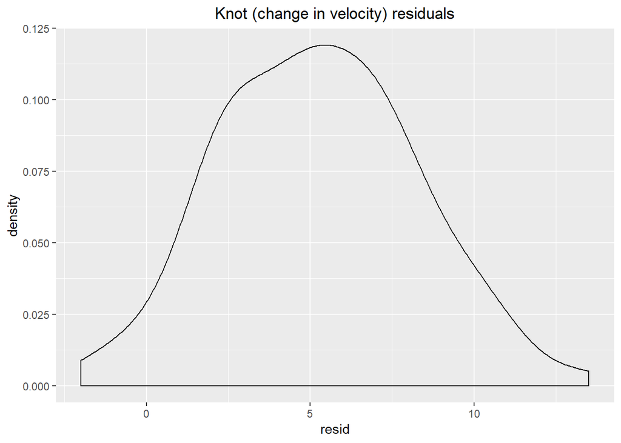

```r
###Knot data

#Check residuals
ship_resid_kt <- ship_data_separated %>%
  mutate(resid = ship_data_separated$knots_Y -
           ship_data_separated$knots_N)

##evaluate residuals visually
ggplot(ship_resid_kt,
       mapping = aes(x= resid)) +
  geom_density() +  #seems normal
  ggtitle("Knot (change in velocity) residuals") +
  theme(plot.title = element_text(hjust = 0.5))
```

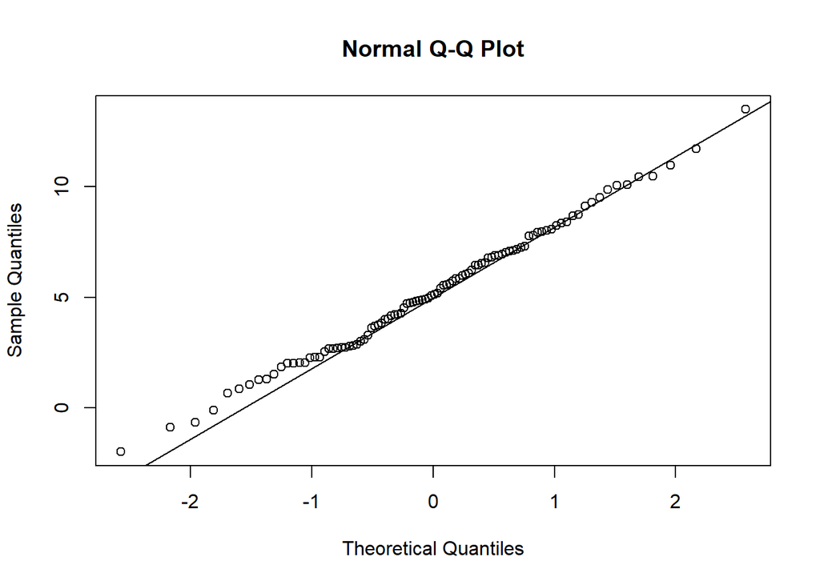

```r
#qq plot
qqnorm(ship_resid_kt$resid)
qqline(ship_resid_kt$resid)
```

```r
#put it to the test
shapiro.test(ship_resid_kt$resid)
```

```
##
##  Shapiro-Wilk normality test
##
## data:  ship_resid_kt$resid
## W = 0.99522, p-value = 0.9804
```

```r
#W = 0.99522, p-value = 0.9804
#failed to reject the null hypothesis, so it is normal
```

##### Figure 8: Testing assumptions of Welch two-sample t-test,Knot predictor data

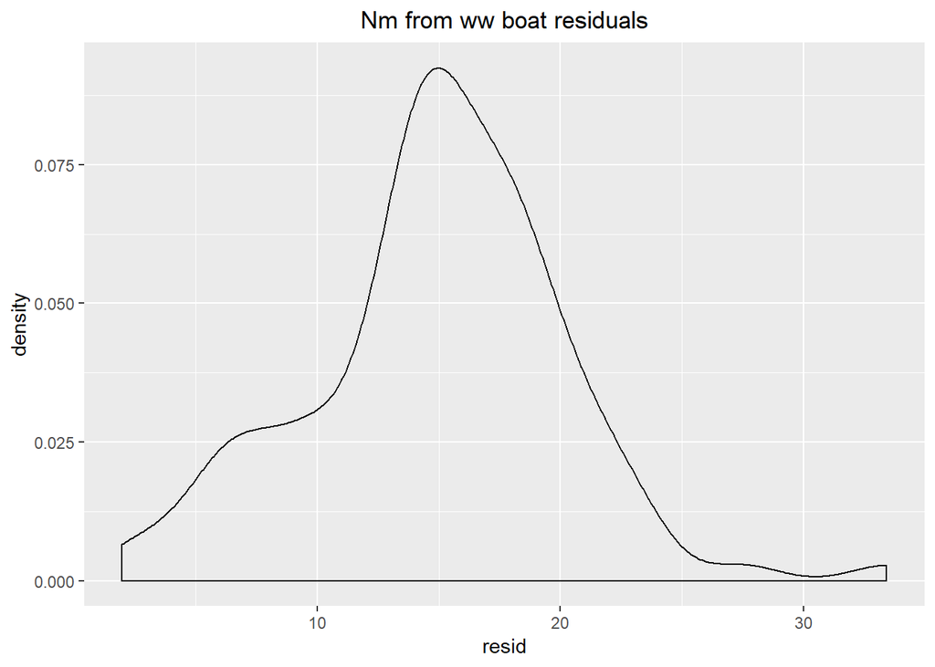

```r
###Nm_from_boat data

#Check residuals
ship_resid_nm <- ship_data_separated %>%
  mutate(resid = ship_data_separated$nm_from_boat_Y -
           ship_data_separated$nm_from_boat_N)

##evaluate residuals visually
ggplot(ship_resid_nm,
       mapping = aes(x= resid)) +
  geom_density() + #not as great
  ggtitle("Nm from ww boat residuals") +
  theme(plot.title = element_text(hjust = 0.5))
```

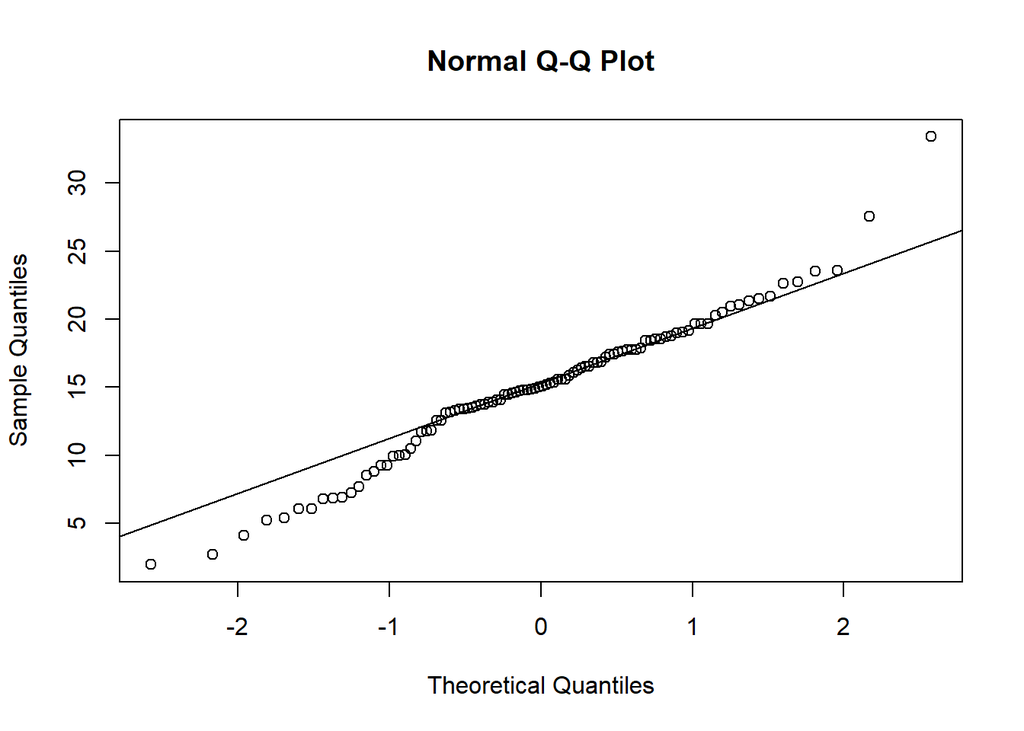

```r
#qq plot
qqnorm(ship_resid_nm$resid)
qqline(ship_resid_nm$resid) #tails are off
```

```r
#put it to the test
shapiro.test(ship_resid_nm$resid)
```

```
##
##  Shapiro-Wilk normality test
##
## data:  ship_resid_nm$resid
## W = 0.97608, p-value = 0.06558
```

```r
#W = 0.97608, p-value = 0.06558
#failed to reject the null hypothesis, so it is normal
```